# Iris

```
  Sepal.Length    Sepal.Width     Petal.Length    Petal.Width
 Min.   :4.300   Min.   :2.000   Min.   :1.000   Min.   :0.100
 1st Qu.:5.100   1st Qu.:2.800   1st Qu.:1.600   1st Qu.:0.300
 Median :5.800   Median :3.000   Median :4.350   Median :1.300
 Mean   :5.843   Mean   :3.057   Mean   :3.758   Mean   :1.199
 3rd Qu.:6.400   3rd Qu.:3.300   3rd Qu.:5.100   3rd Qu.:1.800
 Max.   :7.900   Max.   :4.400   Max.   :6.900   Max.   :2.500
       Species
 setosa    :50
 versicolor:50
 virginica :50
```

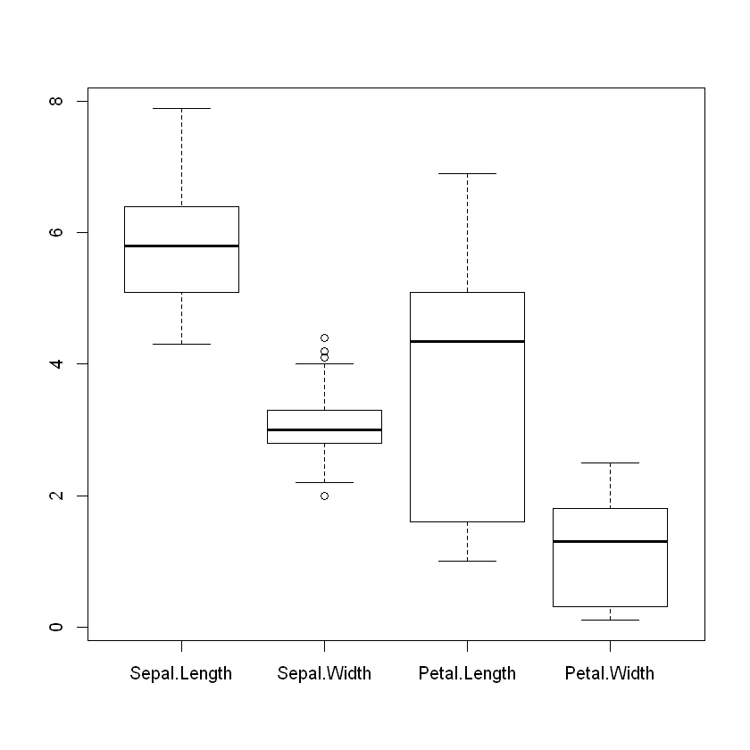

```r
summary(iris)
boxplot(iris[-5])
```

This dataset includes 150 different flowers described by the **sizes** and **width** of two of their attributes: the **petals** and the **sepals**. These values are given in centimetres.  
We can notice that the flowers present in this dataset are part of three different species: **Setosa**, **Versicolor** and **Virginica**. They are equitably distributed in this dataset: 50 records per species.  
It will be interesting to study which characteristic(s) **discriminates** each species and to what extent.  
To do this we will start by analyzing each species in relation to the others, in order to determine if one of the characters is not in the average. If so, we will analyse this character more precisely.

## is one of the parameter of the setosa specie far from the mean

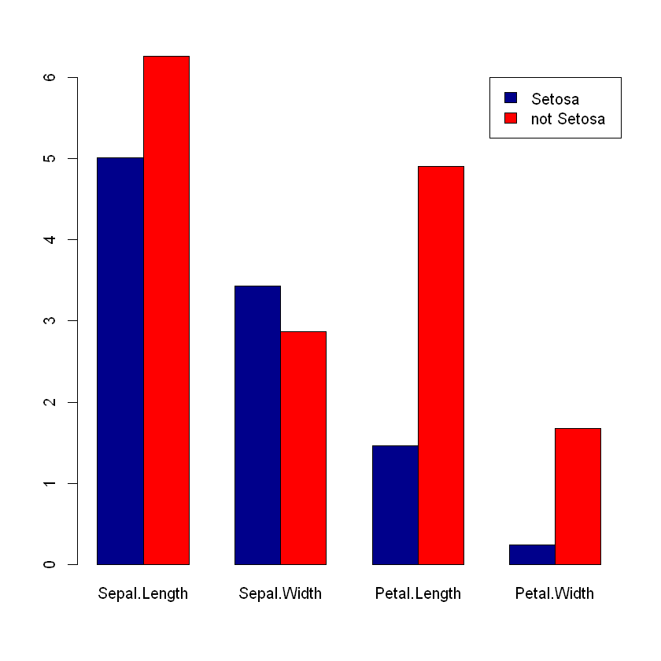

```r
summarySetosa <- c(mean(iris[iris$Species=="setosa", "Sepal.Length"]),mean(iris[iris$Species=="setosa", "Sepal.Width"]),mean(iris[iris$Species=="setosa", "Petal.Length"]),mean(iris[iris$Species=="setosa", "Petal.Width"]))
summaryGlobal <- c(mean(iris[iris$Species!="setosa", "Sepal.Length"]),mean(iris[iris$Species!="setosa", "Sepal.Width"]),mean(iris[iris$Species!="setosa", "Petal.Length"]),mean(iris[iris$Species!="setosa", "Petal.Width"]))
compariason1 <- rbind(summarySetosa,summaryGlobal)

barplot(compariason1,
        beside=T,
        names.arg=c("Sepal.Length","Sepal.Width","Petal.Length","Petal.Width"),
        ylim=c(0,6),
        col=c("darkblue","red"))
legend("topright",
       legend = c("Setosa", "not Setosa"),
       fill = c("darkblue", "red"))
```

## We can see that the petal lenght's mean of the setosa is lower than the mean

## Let's look at what the distribution of the setosa's petal length look compare to the global distribution

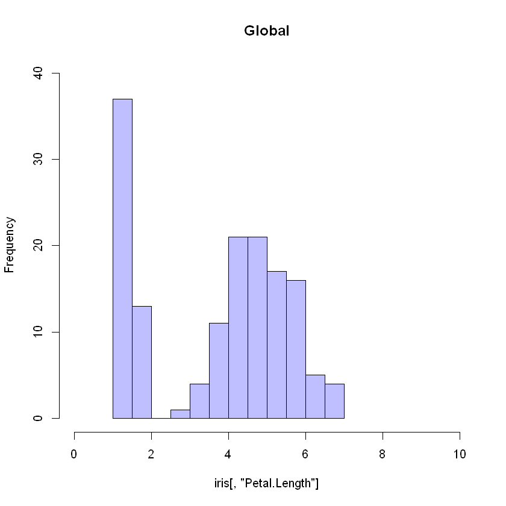

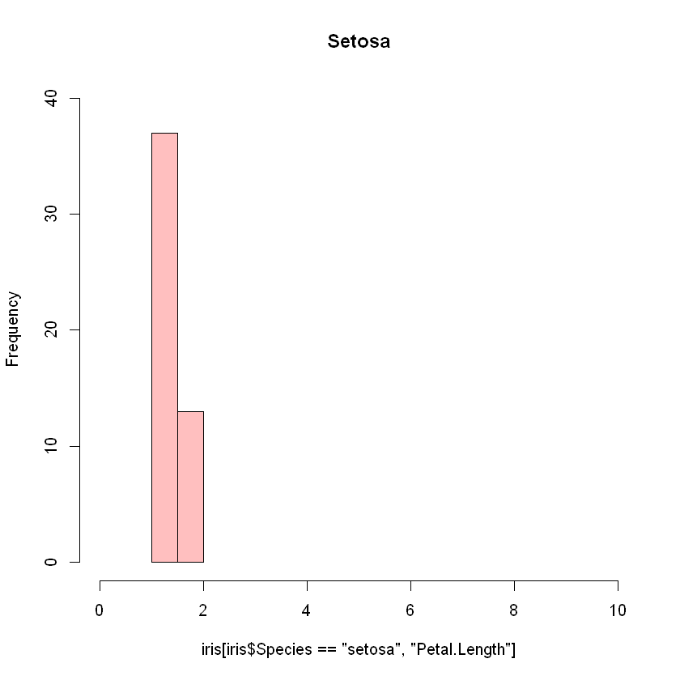

```r
p1 <- hist(iris[iris$Species=="setosa", "Petal.Length"], plot=FALSE, breaks = 2)
p2 <- hist(iris[,"Petal.Length"], plot=FALSE)

plot( p2, col=rgb(0,0,1,1/4),, xlim=c(0,10), ylim=c(0,40),main="Global")
plot( p1, col=rgb(1,0,0,1/4),, xlim=c(0,10), ylim=c(0,40),main="Setosa")
```

```r
setosalt2 <- iris[(iris$Species=="setosa") & (iris$Petal.Length < 2.0), ]
globallt2 <- iris[(iris$Petal.Length < 2.0), ]
paste("proportion of petal between 2 and 5 cm from versicolor :", nrow(setosalt2)/nrow(globallt2)*100, "%")
```

'proportion of petal between 2 and 5 cm from versicolor : 100 %'

## Setosa petal are the smallest, indeed all the petal which are under 2cm are from setosa

## is one of the parameter of the versicolor specie far from the mean

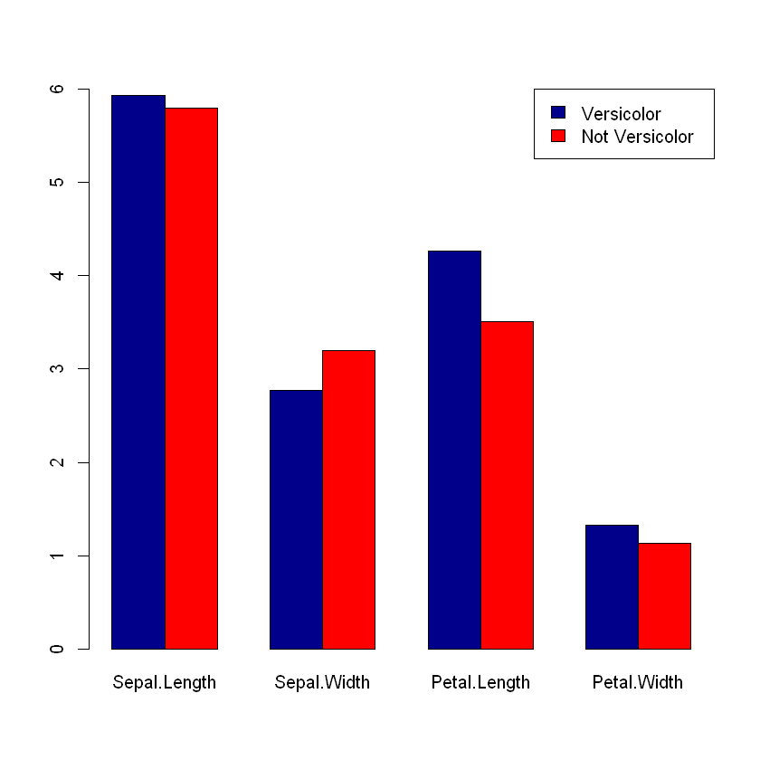

```r
summaryVersicolor <- c(mean(iris[iris$Species=="versicolor", "Sepal.Length"]),mean(iris[iris$Species=="versicolor", "Sepal.Width"]),mean(iris[iris$Species=="versicolor", "Petal.Length"]),mean(iris[iris$Species=="versicolor", "Petal.Width"]))
summaryGlobal <- c(mean(iris[iris$Species!="versicolor", "Sepal.Length"]),mean(iris[iris$Species!="versicolor", "Sepal.Width"]),mean(iris[iris$Species!="versicolor", "Petal.Length"]),mean(iris[iris$Species!="versicolor", "Petal.Width"]))

compariason2 <- rbind(summaryVersicolor,summaryGlobal)
barplot(compariason2,
        beside=T,
        names.arg=c("Sepal.Length","Sepal.Width","Petal.Length","Petal.Width"),
        ylim=c(0,6),
        col=c("darkblue","red"))
legend("topright",
       legend = c("Versicolor", "Not Versicolor"),
       fill = c("darkblue", "red"))
```

## versicolor is in the mean

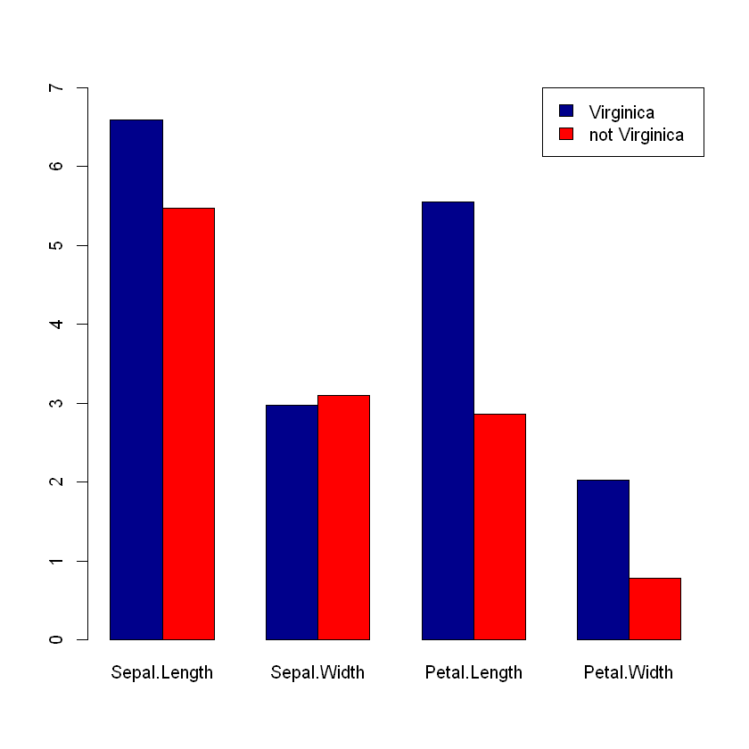

```r
summaryVirginica <- c(mean(iris[iris$Species=="virginica", "Sepal.Length"]),mean(iris[iris$Species=="virginica", "Sepal.Width"]),mean(iris[iris$Species=="virginica", "Petal.Length"]),mean(iris[iris$Species=="virginica", "Petal.Width"]))
summaryGlobal <- c(mean(iris[iris$Species!="virginica", "Sepal.Length"]),mean(iris[iris$Species!="virginica", "Sepal.Width"]),mean(iris[iris$Species!="virginica", "Petal.Length"]),mean(iris[iris$Species!="virginica", "Petal.Width"]))

compariason3 <- rbind(summaryVirginica,summaryGlobal)
barplot(compariason3,
        beside=T,
        names.arg=c("Sepal.Length","Sepal.Width","Petal.Length","Petal.Width"),
        ylim=c(0,7),
        col=c("darkblue","red"))
legend("topright",
       legend = c("Virginica", "not Virginica"),
       fill = c("darkblue", "red"))
```

## Let's look at what the distribution of the virginica's petal length look compare to the global distribution

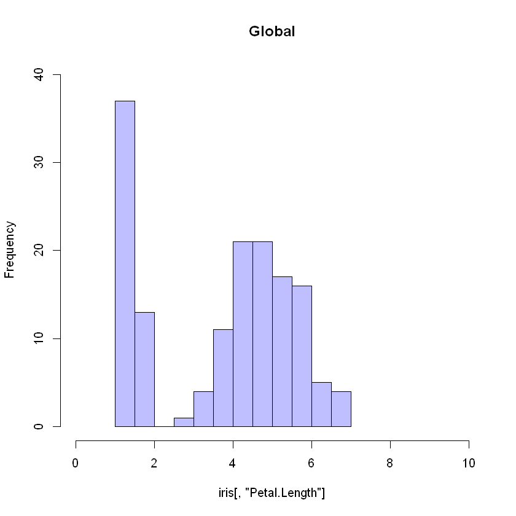

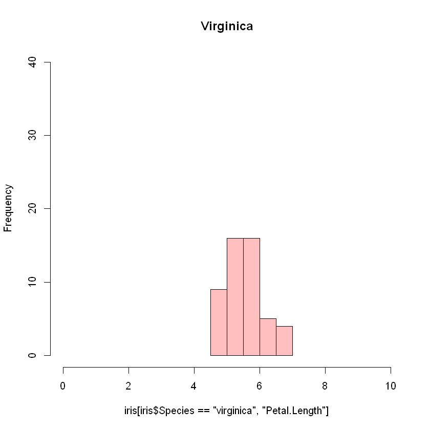

```r
p1 <- hist(iris[iris$Species=="virginica", "Petal.Length"], plot=FALSE)
p2 <- hist(iris[,"Petal.Length"], plot=FALSE)

plot( p2, col=rgb(0,0,1,1/4), xlim=c(0,10), ylim=c(0,40),main="Global")
plot( p1, col=rgb(1,0,0,1/4), xlim=c(0,10), ylim=c(0,40),main="Virginica")
```

## A big part of the petal which are over 5 cm are from virginica

```r
virginicagt5 <- iris[(iris$Species=="virginica") & (iris$Petal.Length >= 5.0), ]
globalgt5 <- iris[(iris$Petal.Length >= 5.0), ]

paste("proportion of petal between 2 and 5 cm from virginica :", nrow(virginicagt5)/nrow(globalgt4)*100, "%")
```

[output not shown]

## if most of the petal over 5 cm are from virginica and all of those which are under 2cm are from setosa, those which are between 2 and five centimeter must be from versicolor

```r
versicolorTest <- iris[(iris$Species=="versicolor") & (iris$Petal.Length <= 5.0) & (iris$Petal.Length >= 2.0), ]
globalTest <- iris[(iris$Petal.Length <= 5.0) & (iris$Petal.Length >= 2.0), ]

paste("proportion of petal between 2 and 5 cm from versicolor :", nrow(versicolorTest)/nrow(globalTest)*100)
```

[output not shown]

## As planned 84% of the petal between 2 and 5cm are from versicolor

```r
virginicaTest <- iris[(iris$Species=="virginica") & (iris$Petal.Length <= 5.0) & (iris$Petal.Length >= 2.0), ]
paste("proportion of petal between 2 and 5 cm from virginica :", nrow(virginicaTest)/nrow(globalTest)*100)
```

'proportion of petal between 2 and 5 cm from virginica : 15.5172413793103'

## The rest are from virginica